# Kundenzufriedenheit: Auswertung einer Umfrage

# Gesamtzufriedenheit und einzelne Aspekte

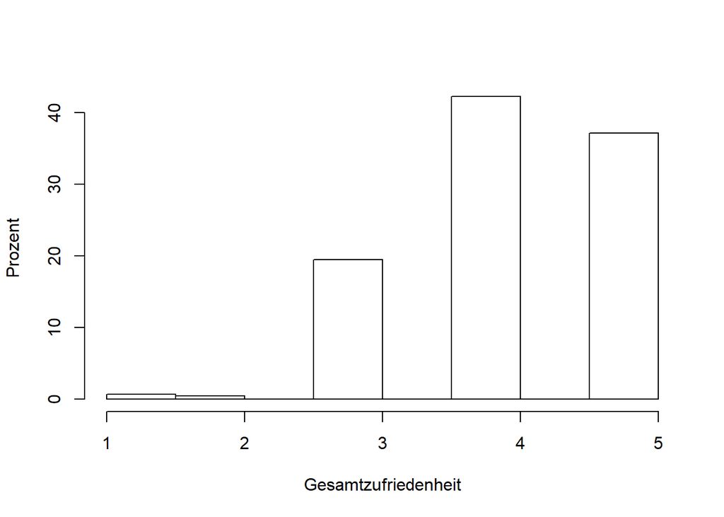

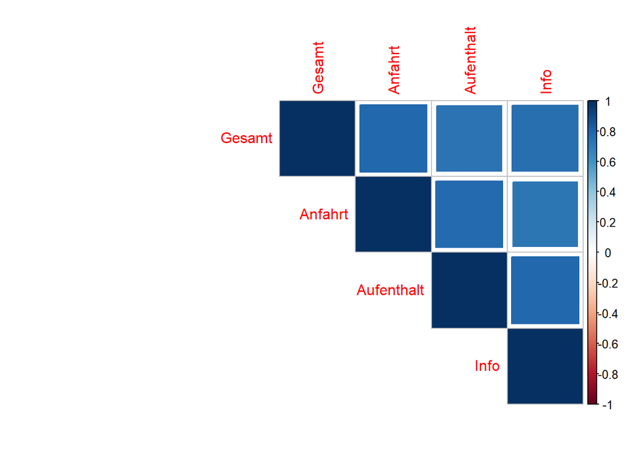

# Grund für die Reise und Zufriedenheit

Die Besucher des Flughafens reisen aus unterschiedlichen Gründen. In unserem Datensatz sind etwa ein Drittel der Befragten Geschäftsreisende. Diese haben unter Umständen Bedürfnisse und Vorstellungen die sich von denen anderer Flugreisender unterscheiden. Tatsächlich zeigt sich ein kleiner Unterschied bei der Bewertung der Anfahrt durch Geschäftsreisende und durch andere Kunden. Geschäftsreisende sind im Schnitt weniger zufrieden mit der Anfahrt (Grafik 5), während es keine Unterschiede bei den Bewertungen der anderen Aspekte (Aufenthalt, Information) gibt. Letzteres überrascht etwas, da Geschäftsreisende u.U. häufiger fliegen und andere Ansprüche an Ihren Aufenthalt im Terminal haben als andere Reisen.

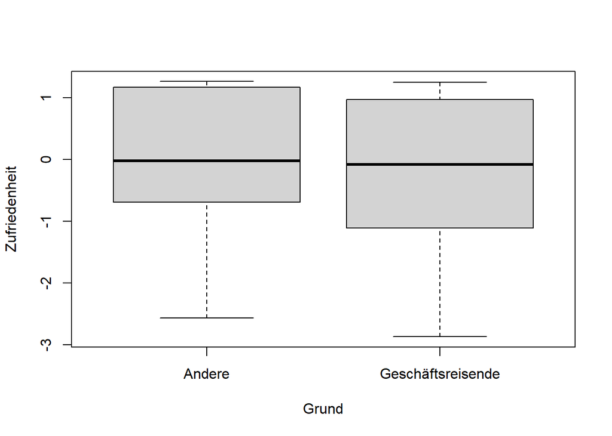

# Fazit

Es gibt kleine Unterschiede in der Zufriedenheit zwischen Geschäftsreisenden und anderen Besuchern des Flughafens. Geschäftsreisende sind im Schnitt etwas weniger mit der Anfahrt zufrieden als andere Fluggäste. In Bezug auf den Aufenthalt und die Informationen gibt es keine Unterschiede. Diese geringen Unterschiede sind erstaunlich, da Geschäftsreisende, die vermutlich häufiger reisen und weniger Zeit mitbringen, ja vermutlich andere Ansprüche an einen Flughafen haben (minimale Wartezeiten, Möglichkeiten während der Wartezeit zu arbeiten) als etwa Urlaubsreisende. Diese Aspekte wurden jedoch nicht direkt erhoben. In einer zukünftiger Befragung könnte man dies ergänzen, während man einige der hoch-korrelierter Indikatoren aus dieser Befragung weglassen könnte.

Durch die Faktoranalyse fallen viele der Befragten aus der Analyse, da zur Berechnung der individuellen scores der einzelnen Faktoren alle zu Grunde liegenden Variablen vorliegen müssen. Insbesondere die Zahl der Urlaubsreisenden wird dadurch drastisch reduziert. Dies könnte die präsentierten Ergebnisse beeinflussen und sollte im Detail untersucht werden.